# Growth Simulations

Elizabeth Hiroyasu

August 31, 2016

Using the lambda values we generated in the LambdaResample.Rmd file, we can simulate the population dynamics of the gopher and owl populations using a simple Lotka Volterra model. Because we know that gopher populations exhibit density dependent growth, we simulate the gopher (prey) growth with the logistic growth function. We also know that barn owls prey on other species when gopher populations are low, so we use a Type III functional response for the owl (predator) population. The Type III function response is characterized by a sigmoidal curve, showing prey switching when the modeled prey is at low densities.

We can write the Lotka Volterra function as follows, then use an ode solver to solve the derivatives.

```r
pred_prey <- function(t, state, parameters){
  with(as.list(c(state, parameters)), {
    #type III Functional response
    dprey=(r*N*(1-(N/K_prey)))-((k_max*(N^2))/((N^2)+(D^2)))*P #with density dependence
    #dprey=(r*N)-((k_max*(N^2))/((N^2)+(D^2)))*P #without density dependence
    #dpredator=0 #constant number of predators
    dpredator= beta*P*N - (delta*P) #incorporating predator

    #return rate of change
    list(c(dprey, dpredator))

  })
}
```

The model requires multiple parameters, defined below: r = growth rate of prey pop (gophers/season) K = carrying capacity of prey alpha = attack rate of predator (or capture efficiency; the larger alpha is, the more the per capita growth rate of the prey population is depressed by the addition of a single predator) beta= assimilation efficiency (efficiency of turning gophers into per capita growth) delta = death rate of predator k_max = maximum feeding rate (1/handling time) D = half saturation constant (1/(alpha*handling time))

State variables: N = starting population of prey P = starting population of predator

For this model, time is in terms of season (3 months), so each time interval is represented by a season and four seasons are equivalent to one year.

```r
alpha=1.68
beta = 0.002
delta=0.01
K_prey=175
h=1.39e-4
k_max=1/h
D=1/(alpha*h)
parameters <- c(r = log(3.47), alpha, beta, delta, K_prey, k_max, D)
state<-c(N = 150, P = 20)
times<- seq(0, 20, by = 0.1)
```

We can use the ODE solver from the deSolve package in R to find solutions to the differential equations

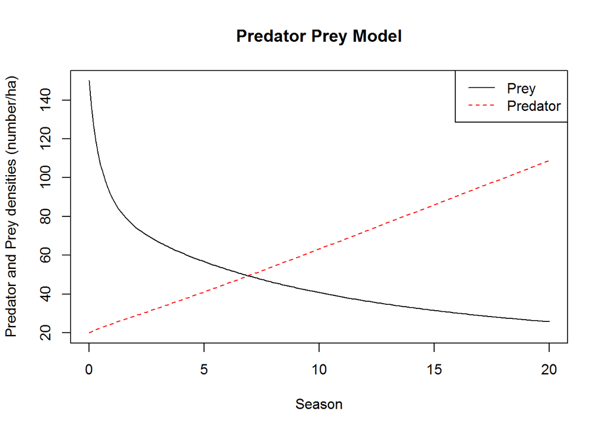

To examine the functional response of the prey as a function of prey abundance:

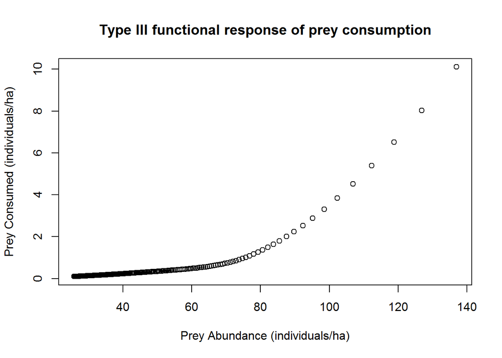

To examine the number of prey consumed over time:

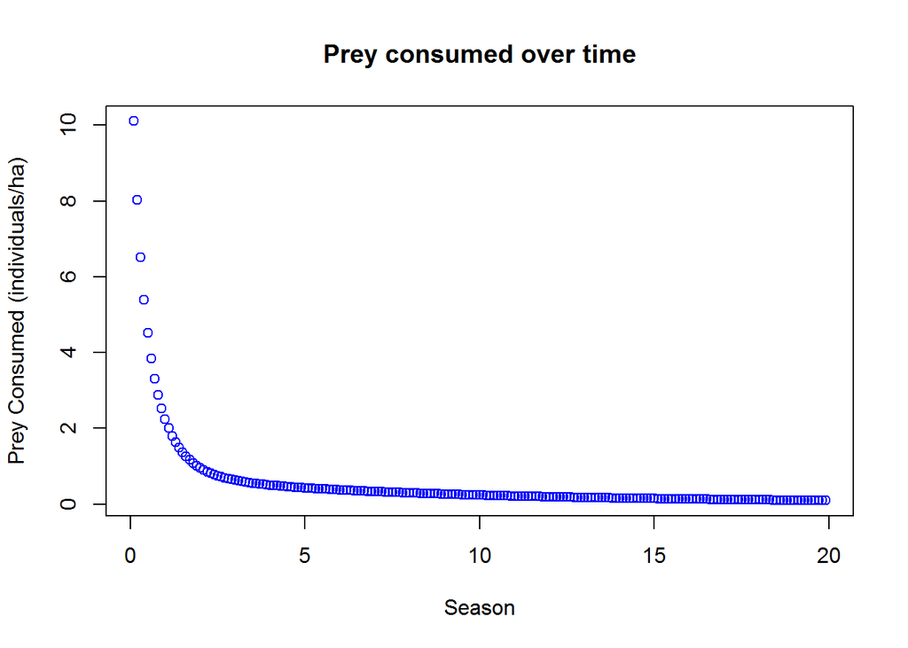

We can also look at how changes in population growth rates of the prey change the equilibrium population size of both the predator and prey species. We can convert lambda values to r values to use in the Lotka Volterra function by taking log(lambda). Any growth rates that are calculated to be negative are dropped from the data, so the data is truncated at zero

First, let’s look at the distribution of r values for each year of simulated data:

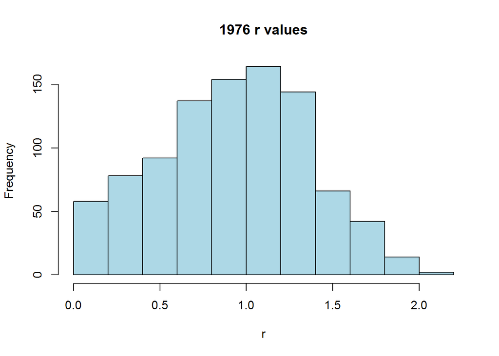

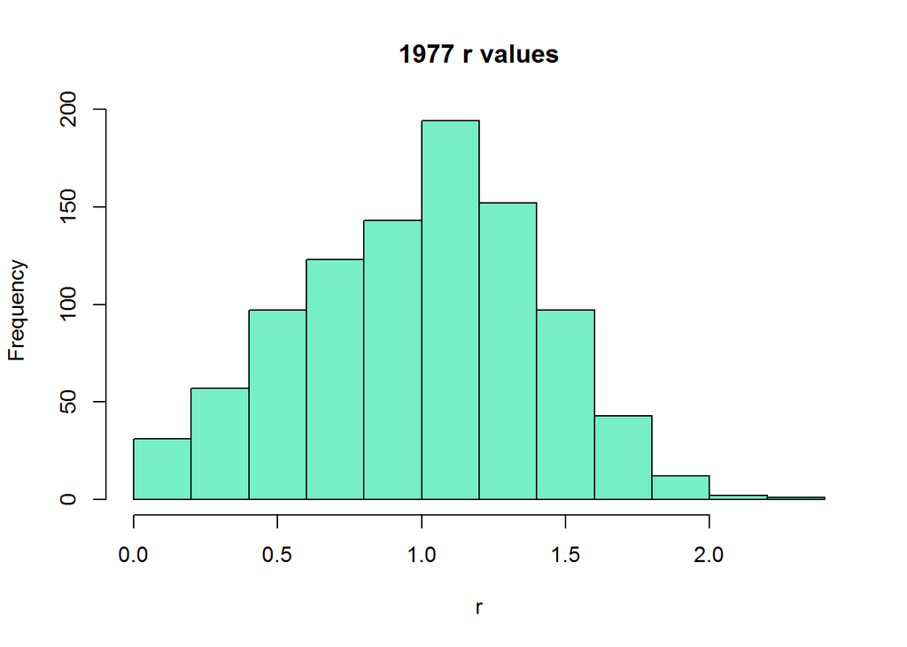

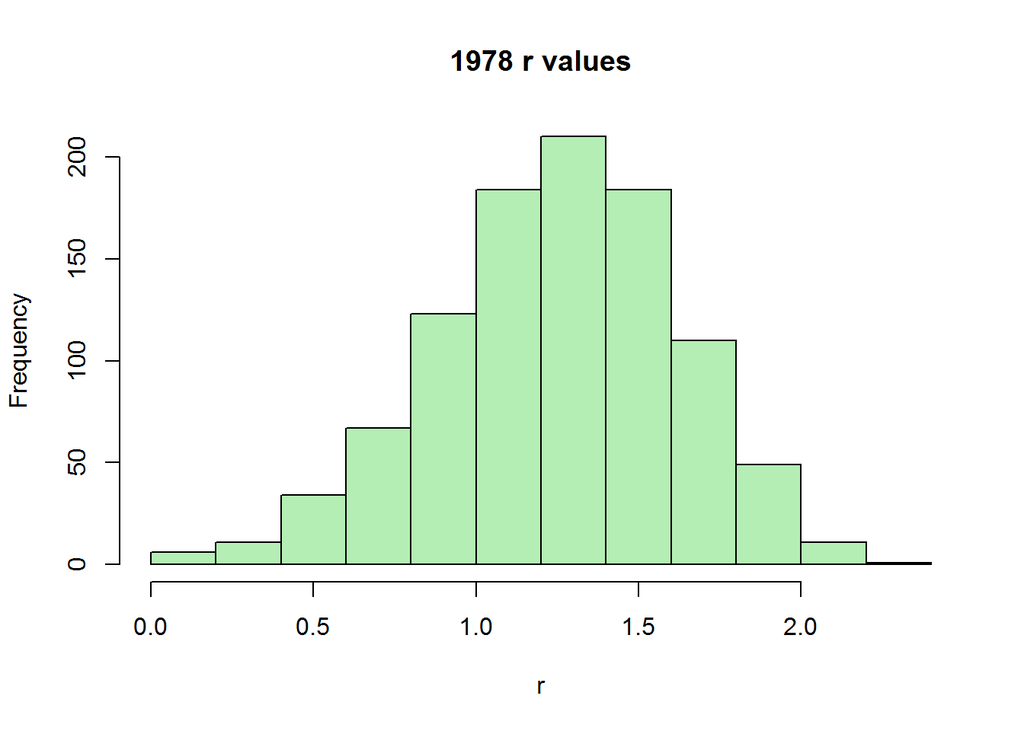

We can then run simulations for these various lists of r values. We assume the same parameter values as the above simulation.

Since we’re looking at 1000 lambda values for each year, it is useful to look at plots for a range of r values at the final time 20 for all three years

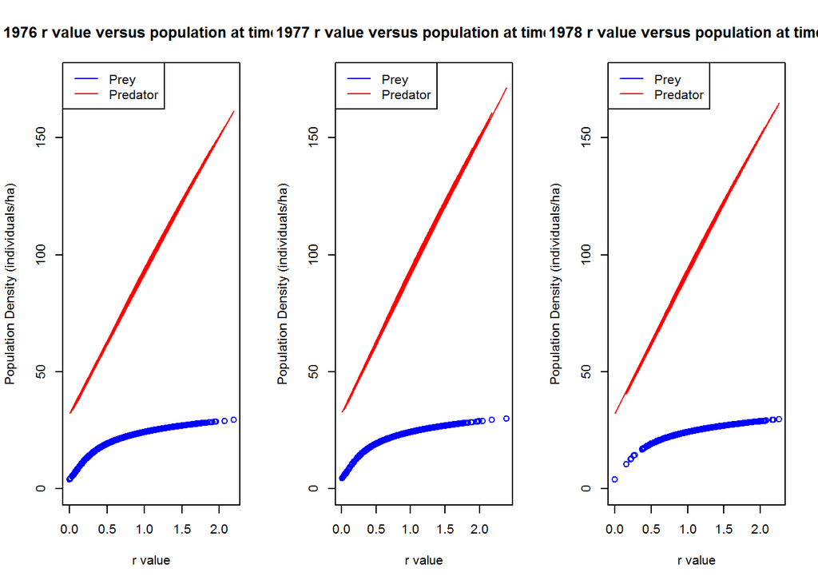

Plotting prey abundance as a function of owl abundance at time 20:

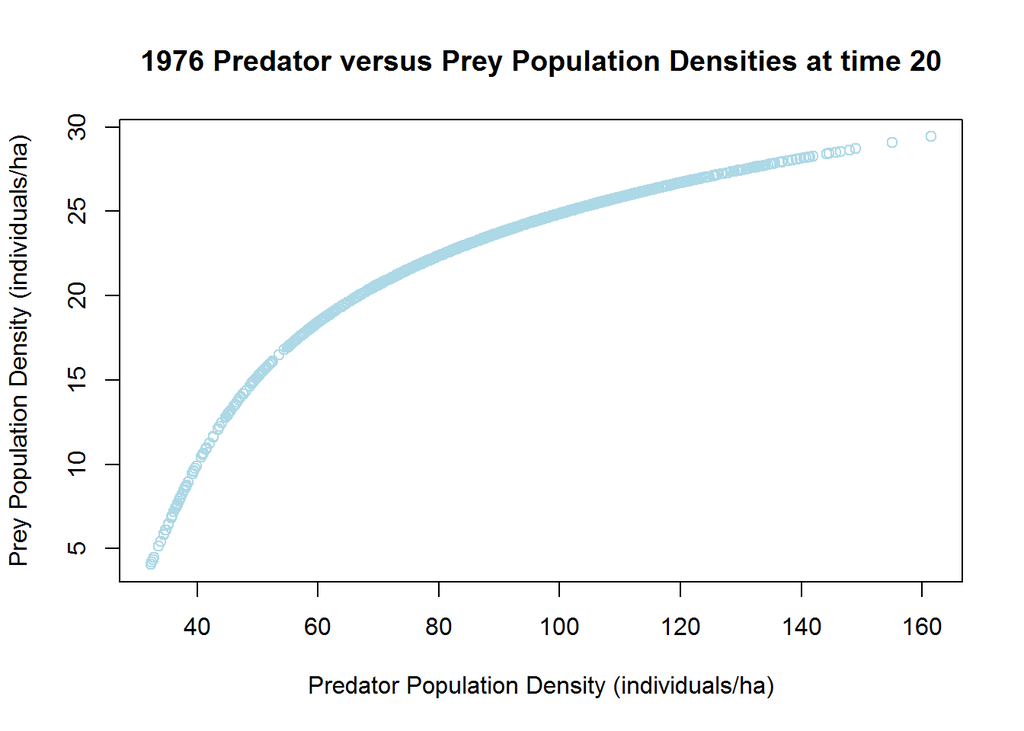

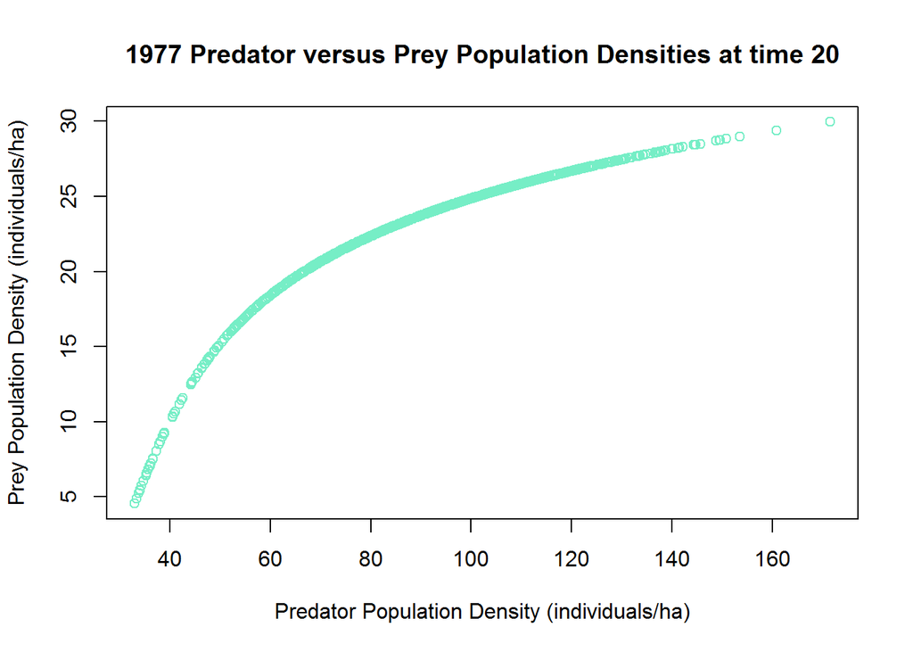

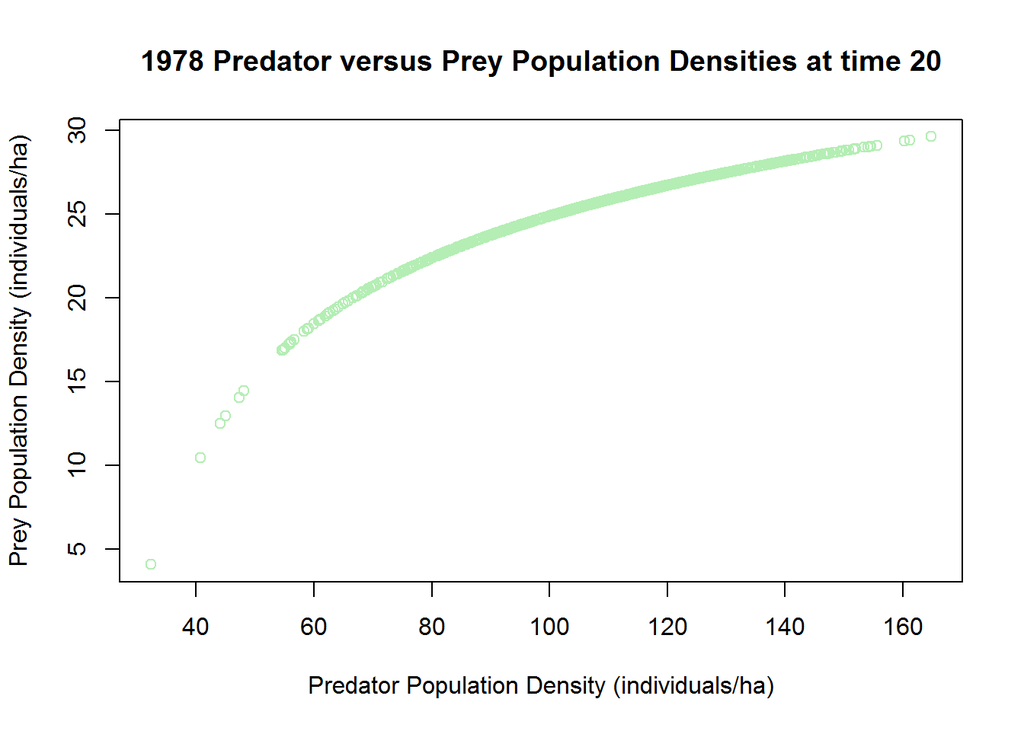

If we are interested in the sensitivity of the predator and prey populations to changes in r values, then we can look at the slope of the curve when we plot the density of the owl population versus the percent change in the prey population.

We can sample the distribution of r-values for each year and look at the slope and position of the relationship between the predator population versus the percent change in prey population.

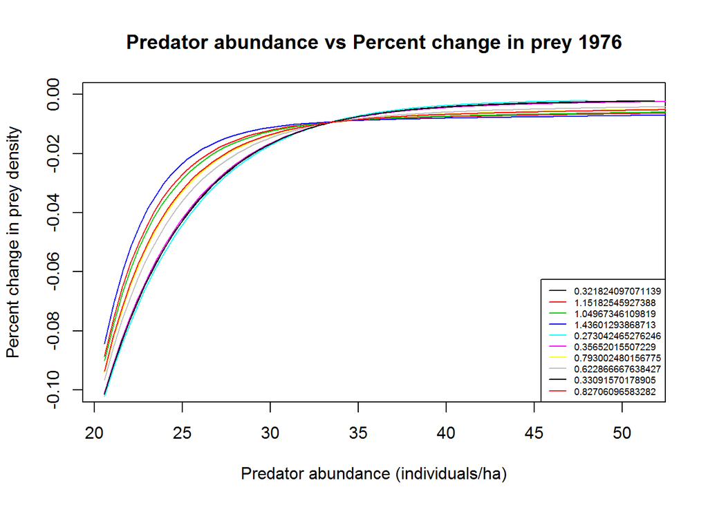

```
##               Df Sum Sq Mean Sq F value   Pr(>F)
## diff           1   1.44    1.44   13.87 0.000201 ***
## P              1  87.51   87.51  845.65  < 2e-16 ***
## Residuals   2007 207.68    0.10
## ---
## Signif. codes:  0 '***' 0.001 '**' 0.01 '*' 0.05 '.' 0.1 ' ' 1
```

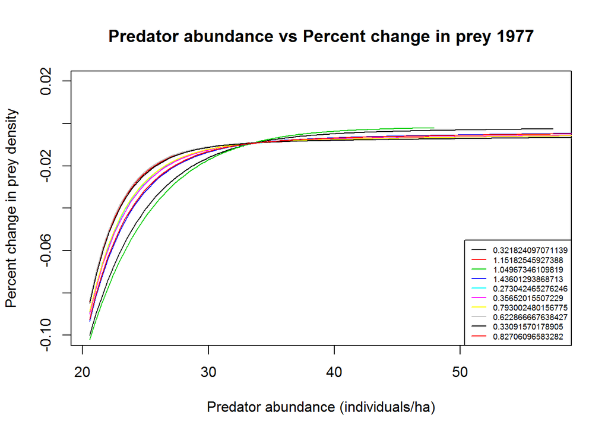

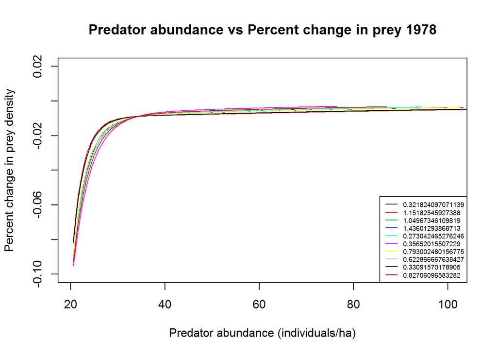